# Human Embryo Case Study

2025-02-25

## About

This tutorial demonstrates the R package [`cpam`](https://github.com/l-a-yates/cpam) for the analysis of time series omics data. It serves an introduction to the package and reproduces the results for the first case study presented in the accompanying [manuscript](https://doi.org/10.1101/2024.12.22.630003) by Yates et al. (2024). The second case study using *Arabidopsis thaliana* time series data is available [here](https://raw.githack.com/l-a-yates/cpam_manuscript/main/R/crisp.html).

## Data

This tutorial uses time-series RNA-seq data tracking human embryo development across multiple stages. The data are publicly available for download [here](https://denis-torre.github.io/embryo-transcriptome/). The data consist of transcript counts for the human preimplantation embryo and are described in original data [manuscript](https://doi.org/10.1038/s41467-023-42558-y) by Torre et al. (2023). The experiment captures transcriptional changes across six early developmental stages: zygote, 2-cell, 4-cell, 8-cell, morula, and blastocyst. These time points span a major developmental transition - embryonic genome activation (EGA) that occurs after the 4-cell stage – and captures major transcriptional transitions in development.

## Installation

You can install `cpam` from GitHub using:

```r
devtools::install_github("l-a-yates/cpam")
```

# Getting started

## Load packages

```r
library(cpam)
library(dplyr)
library(readr)
library(tidyr)
library(stringr)
library(ggplot2)
library(purrr)

directory_path <- "torre/data/"
```

## Load data and transcript-to-gene mapping

We load the transcript counts and the transcript-to-gene mapping. The transcript counts are stored in a matrix where the rows are the transcript IDs and the columns are the samples.

```r
sample_names <- readr::read_tsv(
  paste0(directory_path, "human_embryo-transcript_counts.tsv"),
  n_max = 1,
  col_names = F
) %>%
  t %>% as.vector()

counts <- readr::read_tsv(
  paste0(directory_path, "human_embryo-transcript_counts.tsv"),
  skip = 1,
  col_names = c("target_id", sample_names)
)

count_matrix <- counts %>% dplyr::select(-target_id) %>% as.matrix
rownames(count_matrix) <- counts %>% pull(target_id)

# convert to tibble (for display only)
as.data.frame(count_matrix) %>% head %>% tibble::rownames_to_column("target_id")
```

| target_id | human_2C_B2_1 | human_2C_B3_1 | human_2C_B3_2 | human_2C_B3_4 | human_2C_B3_5 | human_2C_B3_6 | human_2C_B4_1 | human_2C_B4_2 | human_2C_B4_3 | human_2C_B4_4 | human_2C_B4_5 | human_2C_B4_6 | human_2C_B4_7 | human_2PN_B1_1 | human_2PN_B1_2 | human_2PN_B2_1 | human_2PN_B3_1 | human_2PN_B3_2 | human_2PN_B3_3 | human_2PN_B3_4 | human_2PN_B3_5 | human_2PN_B3_7 | human_2PN_B3_8 | human_2PN_B4_1 | human_2PN_B4_2 | human_2PN_B4_3 | human_4C_B2_1 | human_4C_B2_2 | human_4C_B3_1 | … |
| --- | --- | --- | --- | --- | --- | --- | --- | --- | --- | --- | --- | --- | --- | --- | --- | --- | --- | --- | --- | --- | --- | --- | --- | --- | --- | --- | --- | --- | --- | --- |
| ENST00000373020 | 67 | 0 | 0 | 0 | 78 | 0 | 0 | 10 | 0 | 0 | 23 | 0 | 0 | 0 | 0 | 6 | 0 | 12 | 0 | 0 | 0 | 0 | 0 | 2 | 42 | 0 | 0 | 7 | 2 | … |
| ENST00000496771 | 0 | 0 | 0 | 0 | 0 | 0 | 0 | 0 | 0 | 0 | 0 | 0 | 0 | 0 | 0 | 0 | 0 | 0 | 2 | 0 | 0 | 0 | 0 | 0 | 0 | 0 | 0 | 0 | 0 | … |
| ENST00000612152 | 0 | 0 | 0 | 0 | 0 | 0 | 0 | 0 | 7 | 0 | 4 | 22 | 0 | 9 | 0 | 0 | 0 | 0 | 0 | 0 | 0 | 0 | 0 | 0 | 0 | 0 | 0 | 0 | 0 | … |
| TALONT000541951 | 86 | 0 | 0 | 0 | 45 | 1 | 0 | 5 | 8 | 0 | 43 | 18 | 0 | 5 | 0 | 12 | 0 | 5 | 0 | 0 | 0 | 0 | 0 | 22 | 44 | 0 | 3 | 8 | 3 | … |
| TALONT000541959 | 0 | 0 | 3 | 1 | 0 | 0 | 6 | 0 | 0 | 0 | 0 | 8 | 0 | 0 | 0 | 1 | 0 | 0 | 0 | 4 | 0 | 0 | 0 | 5 | 20 | 0 | 0 | 0 | 0 | … |
| TALONT000541968 | 0 | 1 | 3 | 0 | 6 | 0 | 0 | 0 | 0 | 0 | 0 | 2 | 0 | 3 | 0 | 4 | 0 | 0 | 0 | 0 | 0 | 0 | 0 | 0 | 0 | 0 | 0 | 0 | 0 | … |

The transcript-to-gene mapping is a data frame with two columns, target_id and gene_id.

```r
transcriptome <- readr::read_tsv(paste0(directory_path,"Human_embryo_isoform_transcriptome_GRCh38-isoform_classification.tsv"))

t2g <- transcriptome %>%
  select(target_id = transcript_id, gene_id) %>%
  filter(target_id %in% rownames(count_matrix))

t2g
```

| target_id | gene_id |
| --- | --- |
| ENST00000373020 | ENSG00000000003 |
| ENST00000496771 | ENSG00000000003 |
| ENST00000612152 | ENSG00000000003 |
| TALONT000541951 | ENSG00000000003 |
| TALONT000541959 | ENSG00000000003 |
| TALONT000541968 | ENSG00000000003 |
| TALONT000541975 | ENSG00000000003 |
| ENST00000485971 | ENSG00000000005 |
| ENST00000371582 | ENSG00000000419 |
| ENST00000371584 | ENSG00000000419 |

[output cut: 9990 more lines]

## Experimental design

```r
stage_to_time <- tibble(stage = c("2PN","2C","4C","8C","morula","blastocyst"),
                        time = c(0.71,1.5,2,3,4.5,5.5))

ed <-
  tibble(sample = colnames(count_matrix)) %>%
  mutate(stage = str_match(sample,"_(.*?)_")[,2]) %>%
  left_join(stage_to_time, by = "stage")

ed
```

| sample | stage | time |
| --- | --- | --- |
| human_2C_B2_1 | 2C | 1.50 |
| human_2C_B3_1 | 2C | 1.50 |
| human_2C_B3_2 | 2C | 1.50 |
| human_2C_B3_4 | 2C | 1.50 |
| human_2C_B3_5 | 2C | 1.50 |
| human_2C_B3_6 | 2C | 1.50 |
| human_2C_B4_1 | 2C | 1.50 |
| human_2C_B4_2 | 2C | 1.50 |
| human_2C_B4_3 | 2C | 1.50 |
| human_2C_B4_4 | 2C | 1.50 |

[output cut: 63 more lines]

## Fitting the models

To fit the models, we first prepare the `cpam` object, then compute p-values, estimate the changepoint, and select the shape for each transcript. For this analysis, the count data are supplied as a matrix (see this [case study](https://raw.githack.com/l-a-yates/cpam_manuscript/main/R/crisp.html) for importing data directly from common quantification software). We keep all transcripts that have more than 20 reads in at least 3/5 of the samples.

```r
cpo <- prepare_cpam(
  exp_design = ed,
  count_matrix = count_matrix,
  model_type = "case-only",
  filter_fun_args = list(min_reads = 20, min_prop = 3/5),
  t2g = t2g,
  num_cores = 4
)
cpo <- compute_p_values(cpo) # 00:03:37 hms
cpo <- estimate_changepoint(cpo) # 00:23:26 hms
cpo <- select_shape(cpo) #  00:37:28 hms
```

For larger transcriptomes, such as this human transciptome with many additional transcripts beyond the standard reference, the model fitting can take a long time. Here, using 4 cores, we were able to estimate $p$-values in 3 minutes, changepoints in 23 minutes, and shape selections in 37 minutes. The latter stages, although slower to compute, are worth the wait for the inferences they provide.

We can look at a summary of the fitted cpam object

```r
cpo
## cpam object
## -----------
## case-only time series
## 73 samples
## 6 time points
```

If you run the code on your own computer, you can launch the Shiny app to visualise the results interactively using `visualise(cpo)`.

## Results

The results of the analysis are summarised using the `results` function. Here we use the default settings for log-fold change and p-value thresholds.

```r
res <- results(
  cpo,
  min_lfc = 0,
  p_threshold = 0.05,
  add_counts = T,
  add_lfc = F
)

res
```

| target_id | gene_id | p | cp | shape | counts.1.5 | counts.0.71 | counts.2 | counts.3 | counts.5.5 | counts.4.5 |
| --- | --- | --- | --- | --- | --- | --- | --- | --- | --- | --- |
| ENST00000002125 | ENSG00000003509 | 0 | 2.00 | ilin | 1.059781e+02 | 1.059781e+02 | 1.059781e+02 | 1.765412e+02 | 6.322961e+02 | 3.795690e+02 |
| ENST00000003302 | ENSG00000048028 | 0 | 3.00 | micv | 5.677703e+00 | 5.677703e+00 | 5.677703e+00 | 5.677703e+00 | 1.877049e+02 | 4.631850e+01 |
| ENST00000003583 | ENSG00000001460 | 0 | 2.00 | cv | 7.419722e+01 | 7.419722e+01 | 7.419722e+01 | 3.885095e+01 | 4.341507e+00 | 1.051657e+01 |
| ENST00000005082 | ENSG00000005801 | 0 | 4.50 | ilin | 9.896079e+01 | 9.896079e+01 | 9.896079e+01 | 9.896079e+01 | 5.465272e+02 | 9.896079e+01 |
| ENST00000005259 | ENSG00000075790 | 0 | 4.50 | ilin | 2.036722e+02 | 2.036722e+02 | 2.036722e+02 | 2.036722e+02 | 9.262782e+02 | 2.036722e+02 |
| ENST00000005558 | ENSG00000006652 | 0 | 1.50 | cx | 1.797543e+00 | 1.797543e+00 | 9.284337e-04 | 2.180968e-03 | 2.587533e+02 | 2.088929e+00 |
| ENST00000007390 | ENSG00000007520 | 0 | 3.00 | cv | 3.341741e+01 | 3.341741e+01 | 3.341741e+01 | 3.341741e+01 | 1.543552e+03 | 3.331976e+02 |
| ENST00000007516 | ENSG00000004779 | 0 | 2.00 | ilin | 7.138567e+03 | 7.138567e+03 | 7.138567e+03 | 1.210251e+04 | 4.529363e+04 | 2.671607e+04 |
| ENST00000009180 | ENSG00000010278 | 0 | 3.00 | ilin | 8.468602e+02 | 8.468602e+02 | 8.468602e+02 | 8.468602e+02 | 4.617758e+03 | 2.343060e+03 |
| ENST00000009589 | ENSG00000008988 | 0 | 0.71 | micv | 1.888922e+03 | 6.121870e+02 | 3.514915e+03 | 9.824019e+03 | 3.677619e+04 | 2.687093e+04 |

[output cut: 9990 more lines]

Using the results table, we can plot the number of differentially expressed genes at each time point.

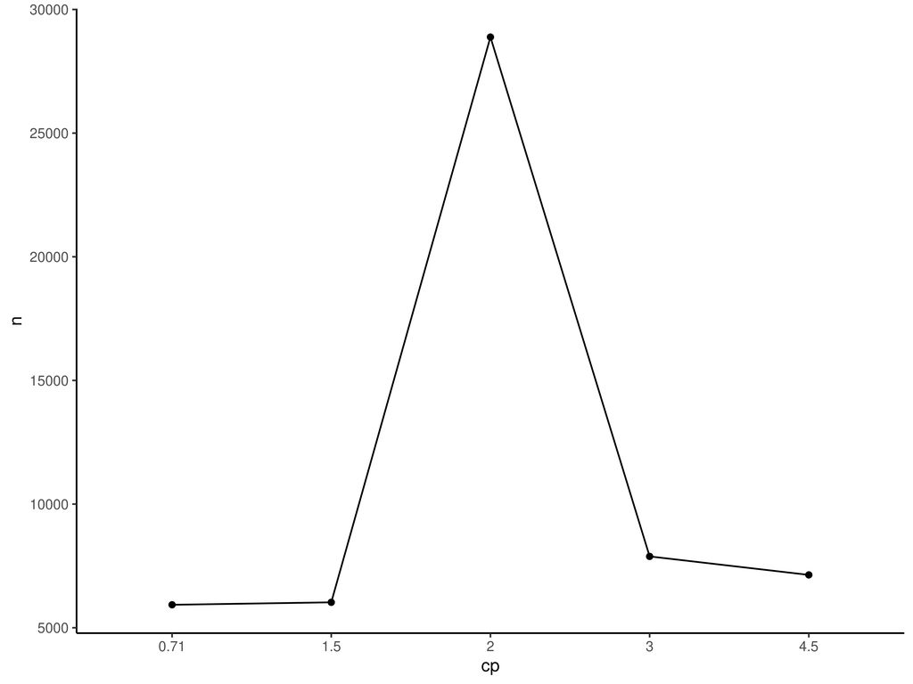

```r
res %>%
  pull(cp) %>%
  table %>%
  {tibble(cp = names(.), n = as.numeric(.))} %>%
  ggplot(aes(cp, n)) +
  geom_point() +
  geom_line(aes(group = 1)) +
  theme_classic()
```

## Plotting

To plot the fitted models for a specific gene, we can use the `plot_cpam` function.

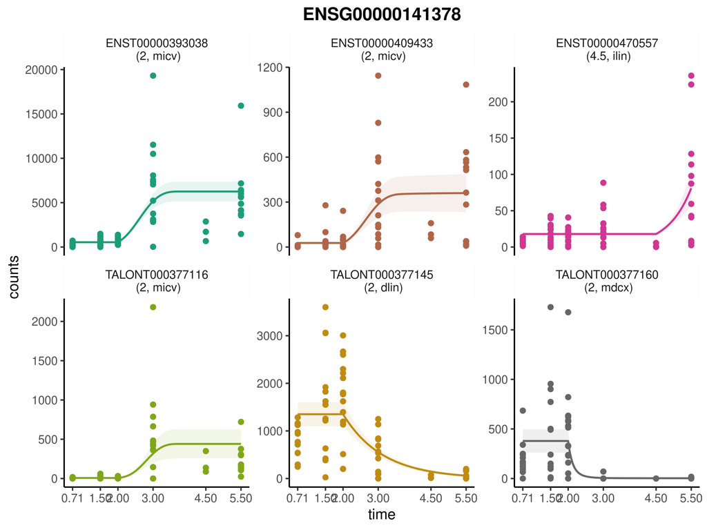

```r
g <- "ENSG00000141378"
plot_cpam(
  cpo,
  gene_id = g,
  facet = T, # plot each transcript on a separate facet
  remove_null = T, # do show transcripts with null trajectories
  common_y_scale = F # do not use a common y scale
)
```

The `facet` argument can be set to FALSE to plot all the fits on the same plot.

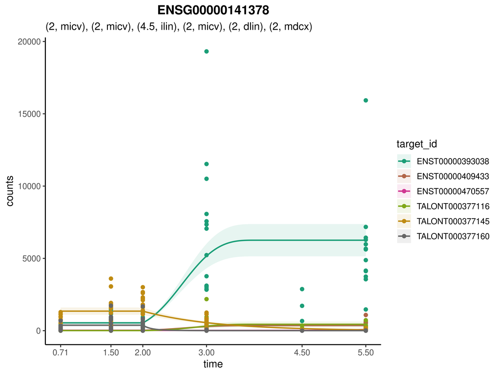

```r
g <- "ENSG00000141378"
plot_cpam(cpo,
          gene_id = g,
          facet = F, # plot each transcript in a common plot
          remove_null = T)
```

## Customising the plot

If you require more customisation than the `plot_cpam` function allows, you can extract the model fits and plot their predictions manually. Here we make a logged version of the above plot with some extra customisations such as changepoint ticks.

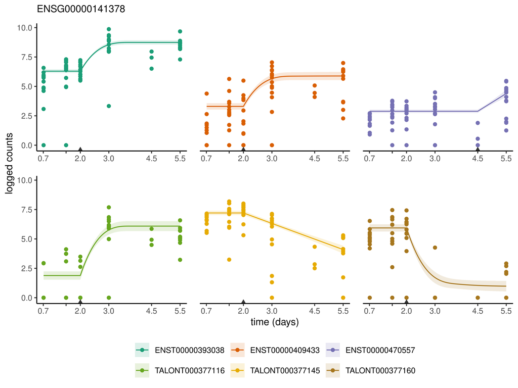

```r
# set gene
g <- "ENSG00000141378"

# set logged
logged <- T
if(logged) fun <- function(x) log(x + 0.5) else fun <- identity
scls <- if_else(logged, "free_x", "free")

# get data
obs <-
  cpo$data_long %>%
  filter(gene_id == g) %>%
  transmute(target_id, time, counts = fun(counts_raw/norm_factor + 0.5))
cps <- cpo$changepoints %>% filter(target_id %in% unique(obs$target_id))

# set colours
tx_cols <- c(RColorBrewer::brewer.pal(7, name = "Dark2"))[-4]

# plot
plot_cpam(cpo, gene_id = g, return_fits_only = T) %>%
  map_dfr( ~ cpam:::predict_cpgam(.x, logged = logged), .id = "target_id") %>%
  ggplot(aes(time, counts)) +
  scale_x_continuous(breaks = round(sort(cpo$times), 1),
                     labels = c("0.7", "", "2.0", "3.0", "4.5", "5.5")) +
                     geom_line(aes(col = target_id)) +
                       geom_ribbon(aes(ymin = q_lo, ymax = q_hi, fill = target_id), alpha = 0.15) +
                       facet_wrap( ~ target_id, scales = scls) +
                       geom_point(data = obs, aes(time, counts, col = target_id)) +
                       scale_fill_manual(values = tx_cols, aesthetics = c("fill", "color")) +
                       theme_classic() +
                       theme(
                         legend.position = "bottom",
                         plot.subtitle = element_text(
                           hjust = 0,
                           face = "plain",
                           margin = margin(b = 10)
                         ),
                         strip.background = element_blank(),
                         strip.text = element_blank(),
                         axis.line.x = element_line(color = "black"),
                         axis.ticks.x = element_line(),
                         panel.spacing.y = unit(1, "lines"),
                         panel.spacing.x = unit(1, "lines"),
                         axis.text.x = element_text(angle = 0, hjust = 0.5)
                       ) +
                       labs(
                         y = "logged counts",
                         x = "time (days)",
                         col = NULL,
                         fill = NULL,
                         subtitle = paste0(g)
                       ) +
                       guides(color = guide_legend(byrow = TRUE), fill = guide_legend(byrow = TRUE)) +
                       geom_point( # add ticks for changepoints
                         data = cps,
                         aes(x = cp_1se, y = -Inf),
                         shape = 17,
                         color = "grey20",
                         size = 2.5
                       )
```

## Clusters

We can identify clusters of targets that have similar expression profiles. In the first instance, we can use the results table with the function `plot_cluster`

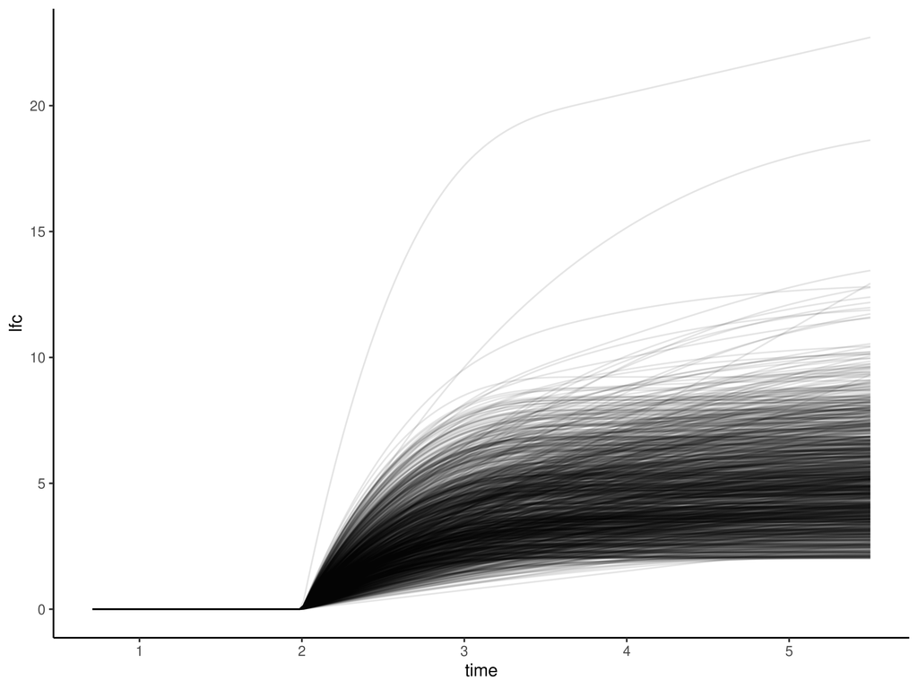

```r
# filter to keep number of targets reasonable
res <- results(cpo, min_lfc = 2, min_count = 1000)

plot_cluster(cpo, res, changepoints = 2.0, shapes = "micv")
```

In this example, we subset the cluster based on the speed of response by calculating the ratio of log-fold changes between the 8-cell (3.0 days) and morula (4.5 days) stages. This ratio captures how quickly genes reach their maximum expression after activation. To manage the scale of the plot, we first filter out a small number of extreme values (log-fold changes above 10), then assign the remaining targets into four sub-clusters using specific thresholds (0.6, 0.75, and 0.87). This flexible clustering approach reveals distinct expression profiles within a cluster that share the same changepoint and shape.

```r
res_cluster <-
  res %>%
  filter(lfc.5.5<10) %>% # remove extreme values
  filter(cp %in% 2, shape %in% "micv") %>% # select the 4C stage and the 'micv' shape
  mutate(rate = lfc.3/lfc.4.5) %>% # calculate the rate/speed
  mutate(cluster = cut(rate,breaks = c(0, 0.6, 0.75, 0.87,10), labels = paste0("cluster ",1:4)))

res_cluster
```

| target_id | gene_id | p | cp | shape | lfc.1.5 | lfc.0.71 | lfc.2 | lfc.3 | lfc.5.5 | lfc.4.5 | counts.1.5 | counts.0.71 | counts.2 | counts.3 | counts.5.5 | counts.4.5 | rate | cluster |
| --- | --- | --- | --- | --- | --- | --- | --- | --- | --- | --- | --- | --- | --- | --- | --- | --- | --- | --- |
| ENST00000031146 | ENSG00000029364 | 0.000000e+00 | 2 | micv | 0 | 0 | 0 | 3.4113432 | 7.266181 | 6.382910 | 7.272320 | 7.272320 | 7.272320 | 77.37303 | 1119.467 | 606.9046 | 0.5344495 | cluster 1 |
| ENST00000084795 | ENSG00000063177 | 0.000000e+00 | 2 | micv | 0 | 0 | 0 | 2.7995833 | 3.558848 | 3.451928 | 172.854074 | 172.854074 | 172.854074 | 1203.47802 | 2037.040 | 1891.5305 | 0.8110203 | cluster 3 |
| ENST00000184266 | ENSG00000065518 | 0.000000e+00 | 2 | micv | 0 | 0 | 0 | 2.6206755 | 6.213513 | 5.283606 | 89.963720 | 89.963720 | 89.963720 | 553.31105 | 6676.075 | 3504.2188 | 0.4960013 | cluster 1 |
| ENST00000196551 | ENSG00000083845 | 0.000000e+00 | 2 | micv | 0 | 0 | 0 | 2.1625632 | 2.668109 | 2.603910 | 4071.712088 | 4071.712088 | 4071.712088 | 18229.44563 | 25879.612 | 24753.2385 | 0.8305062 | cluster 3 |
| ENST00000199320 | ENSG00000086189 | 0.000000e+00 | 2 | micv | 0 | 0 | 0 | 2.8060167 | 4.391823 | 4.097121 | 241.431198 | 241.431198 | 241.431198 | 1688.45144 | 5068.316 | 4131.8998 | 0.6848752 | cluster 2 |
| ENST00000202773 | ENSG00000089009 | 0.000000e+00 | 2 | micv | 0 | 0 | 0 | 3.4937149 | 5.382522 | 5.048424 | 509.911299 | 509.911299 | 509.911299 | 5743.90999 | 21271.361 | 16874.1448 | 0.6920407 | cluster 2 |
| ENST00000203630 | ENSG00000089693 | 0.000000e+00 | 2 | micv | 0 | 0 | 0 | 3.1006482 | 4.159641 | 3.993393 | 275.469881 | 275.469881 | 275.469881 | 2362.99190 | 4923.239 | 4387.3801 | 0.7764445 | cluster 3 |
| ENST00000210444 | ENSG00000095380 | 0.000000e+00 | 2 | micv | 0 | 0 | 0 | 5.0406477 | 6.056678 | 5.943519 | 24.674815 | 24.674815 | 24.674815 | 812.15714 | 1642.464 | 1518.5584 | 0.8480914 | cluster 3 |
| ENST00000215565 | ENSG00000099795 | 0.000000e+00 | 2 | micv | 0 | 0 | 0 | 3.1167239 | 5.251302 | 4.607728 | 126.043379 | 126.043379 | 126.043379 | 1093.32030 | 4800.865 | 3073.1546 | 0.6764123 | cluster 2 |
| ENST00000215570 | ENSG00000099800 | 0.000000e+00 | 2 | micv | 0 | 0 | 0 | 5.2938915 | 6.621214 | 6.451376 | 49.946229 | 49.946229 | 49.946229 | 1959.39878 | 4916.848 | 4370.7943 | 0.8205833 | cluster 3 |

[output cut: 1271 more lines]

```r
cluster_plot_data <-
  res_cluster %>%
  pull(target_id) %>%
  set_names() %>%
  map_dfr(~plot_cpam(cpo, target_id = .x, return_fits_only = T) %>%
            cpam:::predict_lfc(),.id = "target_id")
```

Finally, we plot the clusters.

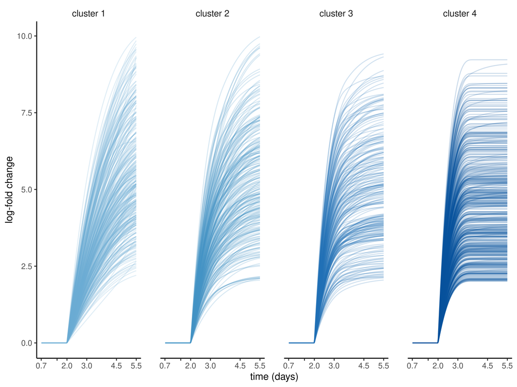

```r
cluster_plot_data %>%
  left_join(res_cluster %>% select(target_id,speed), by = "target_id") %>%
  ggplot(aes(x = time,y = lfc, group = target_id, col = speed)) +
  geom_line(alpha = 0.2) +
  scale_x_continuous(breaks = round(sort(cpo$times),1),
                     labels = c("0.7","","2.0","3.0","4.5","5.5")) +
  scale_color_manual(values = blues9[5:8]) +
  facet_wrap(~ speed, nrow = 1) +
  theme_classic() +
  theme(legend.position = "none",
        strip.background = element_blank(),
        panel.spacing.x = unit(1.5, "lines"),
        strip.text = element_text(size = 10, family = "sans")) +
  labs(title = NULL, subtitle = NULL,
       x = "time (days)", y = "log-fold change")
```

For further, such as GO term enrichment, we can easily extract tables of clustered targets. To look at the numbers of targets in each cluster.

```r
res_cluster %>% pull(cluster) %>% table
## .
## cluster 1 cluster 2 cluster 3 cluster 4
##       318       257       237       469
```

To match targets with their rate and cluster.

```r
res_cluster %>% select(target_id,rate,cluster)
```

| target_id | rate | cluster |
| --- | --- | --- |
| ENST00000031146 | 0.5344495 | cluster 1 |
| ENST00000084795 | 0.8110203 | cluster 3 |
| ENST00000184266 | 0.4960013 | cluster 1 |
| ENST00000196551 | 0.8305062 | cluster 3 |
| ENST00000199320 | 0.6848752 | cluster 2 |
| ENST00000202773 | 0.6920407 | cluster 2 |
| ENST00000203630 | 0.7764445 | cluster 3 |
| ENST00000210444 | 0.8480914 | cluster 3 |
| ENST00000215565 | 0.6764123 | cluster 2 |
| ENST00000215570 | 0.8205833 | cluster 3 |

[output cut: 1271 more lines]

To look at the targets in cluster 1.

```r
res_cluster %>%
  select(target_id,cluster,rate) %>%
  filter(cluster == "cluster 1") %>%
  pull(target_id) %>%
  head() # print first 5 targets
```

```
## [1] "ENST00000031146" "ENST00000184266" "ENST00000216756" "ENST00000225298" "ENST00000225430" "ENST00000228825"
```

## References

Torre, Denis, Nancy J. Francoeur, Yael Kalma, Ilana Gross Carmel, Betsaida S. Melo, Gintaras Deikus, Kimaada Allette, et al. 2023. “Isoform-Resolved Transcriptome of the Human Preimplantation Embryo.” *Nature Communications* 14 (1). https://doi.org/10.1038/s41467-023-42558-y.

Yates, Luke A., Jazmine L. Humphreys, Michael A. Charleston, and Steven M. Smith. 2024. “Shape-Constrained, Changepoint Additive Models for Time Series Omics Data with *Cpam*.” *BioRxiv*, December. https://doi.org/10.1101/2024.12.22.630003.